# Data science beyond Modelling

### Do Computers Lie?

We have been constantly told this statement “Computers don’t lie”. Yes in fact Computers don’t lie, but neither does it speak the truth. A computer does what its Master programs it to do. Similarly, A model wouldn’t lie unless the Machine Learning Engineer doesn’t want it to lie.

### Machine Bias

There was a nice episode of the podcast [You are not so smart](https://youarenotsosmart.com/2017/11/20/yanss-115-how-we-transferred-our-biases-into-our-machines-and-what-we-can-do-about-it/) came out last year. This is an excerpt from it:

*“I want a machine-learning algorithm to learn what tumors looked like in the past, and I want it to become biased toward selecting those kind of tumors in the future,” explains philosopher Shannon Vallor at Santa Clara University. “But I don’t want a machine-learning algorithm to learn what successful engineers and doctors looked like in the past and then become biased toward selecting those kinds of people when sorting and ranking resumes.”*

### The Problem

Machine Bias can occur due to a lot of factors but a few to name is:

- Biased Training Dataset
- Bias Variable in the Feature Space
- BlackBox Modelling of not understanding what’s going on with the Model

Below is an example of how Google Translate, when translated the following text to a Gender-neutral langauge and back to English - applies its bias (primarily due to the nature of biased Training Dataset)

[figure not shown]

### The Solution

The first step of finding solution to any problem is accepting **The Problem exists**. Let’s accept that fact and see how to use Kaggle Survey results and help the community tackle Machine Bias.

### Libraries

```r
suppressPackageStartupMessages(library(tidyverse))
suppressPackageStartupMessages(library(highcharter))
suppressPackageStartupMessages(library(DataExplorer))
suppressPackageStartupMessages(library(scales))
suppressPackageStartupMessages(library(cowplot))
suppressPackageStartupMessages(library(viridis))

plotting_missing <- function(df){

  #based on erikbruin's code snippet

NAcol <- which(colSums(is.na(df)) > 0)
NAcount <- sort(colSums(sapply(df[NAcol], is.na)), decreasing = TRUE)
NADF <- data.frame(variable=names(NAcount), missing=NAcount)
NADF$PctMissing <- round(((NADF$missing/nrow(df))*100),1)
NADF %>%
    ggplot(aes(x=reorder(variable, PctMissing), y=PctMissing)) +
    geom_bar(stat='identity', fill='red') + coord_flip(y=c(0,110)) +
    labs(x="", y="Percent missing") +
    geom_text(aes(label=paste0(NADF$PctMissing, "%"), hjust=-0.1))
}
```

```r
survey <- read_csv("input/multipleChoiceResponses.csv", skip = 1, col_types = cols())
```

### Ignorance is Bliss - but not always!

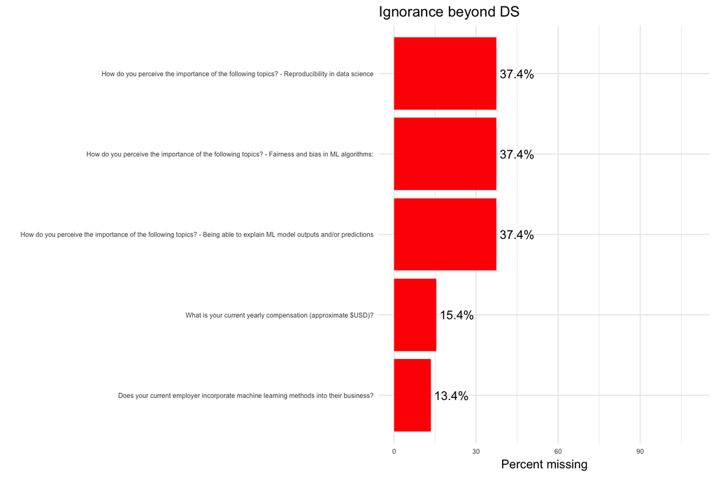

```r
p1  + theme_minimal() + theme(axis.text = element_text(size = 6)) + labs(title = "Ignorance beyond DS")
```

The above plot is to demonstrate how much these questions that are about Model Fairness / Bias, have been ignored.

While asking about **Salary made 15% of respondents** to not answer, Questions about **Reproducibility, Explainability and Bias made 37% of respondents** to skip answering. The salary question comparsion is here to show relatively worse questions like this are approached.

### Reproducibility, Explainability and Bias

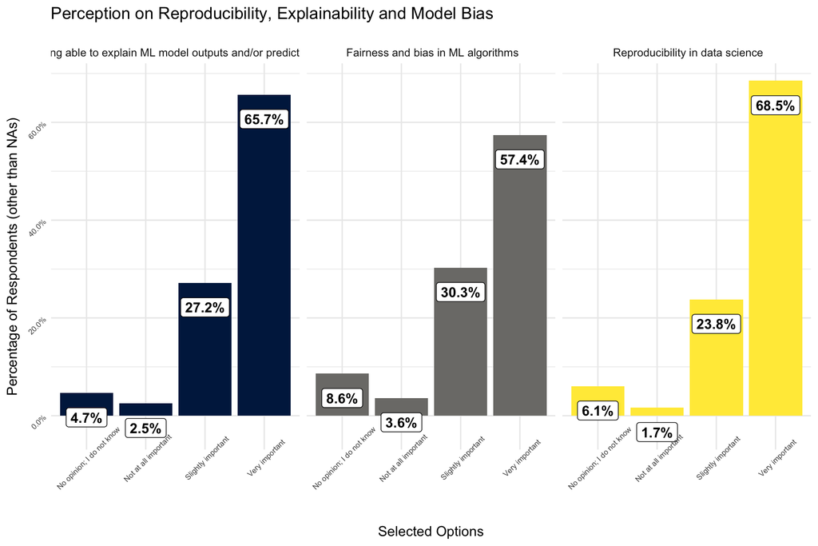

```r
survey %>% select(contains("How do you perceive the importance of the following topics?")) %>%
  gather() %>%
  mutate(key = str_replace(key,"-","\n")) %>%
  mutate(key = str_replace(key,"How do you perceive the importance of the following topics?",""),
         key = str_replace(key, regex("\\?"),""),
         key = str_replace(key, regex("\\-|\\:"),"")) %>%
  group_by(key) %>%
  count(value) %>%
  drop_na() %>%
  mutate(n = n / sum(n)) %>%
  ggplot() + geom_col(aes(value,n, fill = key), stat = "identity", show.legend = FALSE) +
   geom_label(aes(x = value, y = n - 0.05, label = percent(n)),
           # hjust=0, vjust=0, size = 4, colour = 'black',
            fontface = 'bold') +
  scale_fill_viridis(discrete = T, option = "E") +
  facet_wrap(~key) +
  scale_y_continuous(labels = percent_format()) +
  theme_minimal() +
  theme(axis.text = element_text(angle = 45, size = 6)) +
  labs(title = "Perception on Reproducibility, Explainability and Model Bias ",
       x = "Selected Options",
       y = "Percentage of Respondents (other than NAs)")
```

**Fairness and Bias:**

- Only close to half (57.4%) of the respondenrts who chose to answer consider Fairness and Bias in ML Algorithm is a **Very important**.
- This is the lowest **Very important** sentiment echoed by the community of all the 3 questions.
- **3.6%** of those who chose to respondent perceive this is **Not at all important**, which is the highest **Not at all important** feeling expressed of all 3 questions.

```r
survey %>% select(contains("How do you perceive the importance of the following topics?")) %>%
  gather() %>%
  mutate(key = str_replace(key,"How do you perceive the importance of the following topics?",""),
         key = str_replace(key, regex("\\?"),""),
         key = str_replace(key, regex("\\-"),"")) %>%
  group_by(key) %>%
  count(value) %>%
  mutate(n = percent(n / sum(n)))  %>%
  spread(value,n) %>%
  knitr::kable()
```

| key | No opinion; I do not know | Not at all important | Slightly important | Very important |  |
| --- | --- | --- | --- | --- | --- |
| Being able to explain ML model outputs and/or predictions | 2.9% | 1.6% | 17.0% | 41.1% | 37.4% |
| Fairness and bias in ML algorithms: | 5.4% | 2.3% | 19.0% | 36.0% | 37.4% |
| Reproducibility in data science | 3.8% | 1.0% | 14.9% | 42.9% | 37.4% |

## Who are they?

*They* refer to those beings who think Fairness and Bias are **Very Important** in Machine Learning.

```r
they <- survey %>% filter(`How do you perceive the importance of the following topics? - Fairness and bias in ML algorithms:` == "Very important")


not_they <- survey %>% filter(`How do you perceive the importance of the following topics? - Fairness and bias in ML algorithms:` != "Very important")
```

### Gender

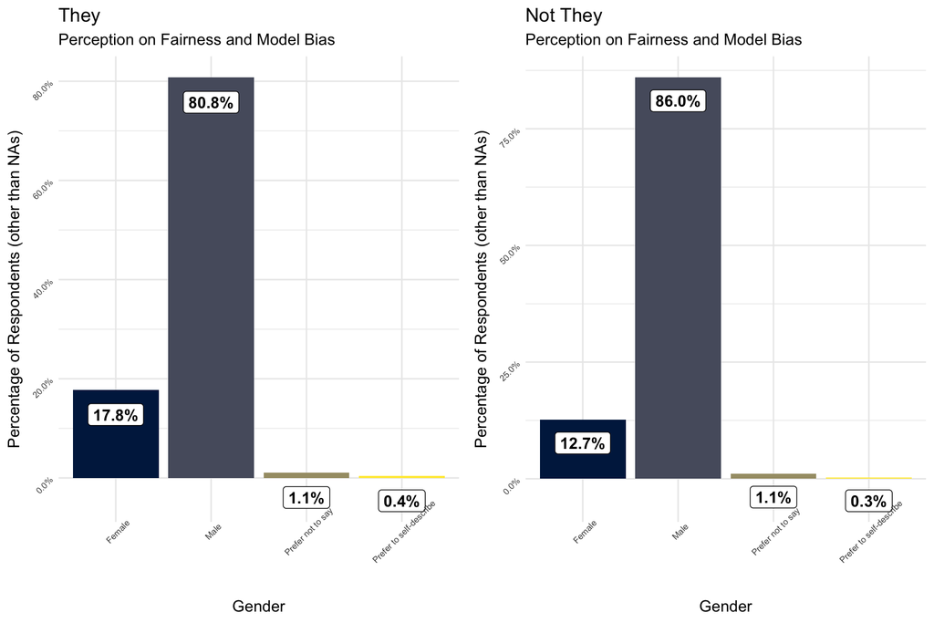

```r
they %>% group_by(`What is your gender? - Selected Choice`) %>% count() %>% ungroup() %>%
  rename("Gender" = `What is your gender? - Selected Choice`) %>%
  mutate(n = n / sum(n),
         perc = percent(n)) %>%
   ggplot() + geom_col(aes(Gender,n, fill = Gender), stat = "identity", show.legend = FALSE) +
   geom_label(aes(x = Gender, y = n - 0.05, label = percent(n)),
           # hjust=0, vjust=0, size = 4, colour = 'black',
            fontface = 'bold') +
    scale_fill_viridis(discrete = T, option = "E") +

  scale_y_continuous(labels = percent_format()) +
  theme_minimal() +
  theme(axis.text = element_text(angle = 45, size = 6)) +
  labs(title = "They",
       subtitle = "Perception on Fairness and Model Bias ",
       x = "Gender",
       y = "Percentage of Respondents (other than NAs)") -> p1
not_they %>% group_by(`What is your gender? - Selected Choice`) %>% count() %>% ungroup() %>%
  rename("Gender" = `What is your gender? - Selected Choice`) %>%
  mutate(n = n / sum(n),
         perc = percent(n)) %>%
    ggplot() + geom_col(aes(Gender,n, fill = Gender), stat = "identity", show.legend = FALSE) +
   geom_label(aes(x = Gender, y = n - 0.05, label = percent(n)),
           # hjust=0, vjust=0, size = 4, colour = 'black',
            fontface = 'bold') +
    scale_fill_viridis(discrete = T, option = "E") +

  scale_y_continuous(labels = percent_format()) +
  theme_minimal() +
  theme(axis.text = element_text(angle = 45, size = 6)) +
  labs(title = "Not They",
       subtitle = "Perception on Fairness and Model Bias ",
       x = "Gender",
       y = "Percentage of Respondents (other than NAs)") -> p2
cowplot::plot_grid(p1,p2)
```

- There is a difference of **5.1 PP** Female Percentage difference between those who perceive **Model Fariness & Bias in ML** is **Very Important** and Others.
- While this could be seen as that **Female Gender** usually gets affected by these Biases, It’s also important to realize that **Male Gender** (Kaggler’s) don’t echo similar sentiment as their female counterpart. After all, A healthy model is what we all want, don’t we?

### Age

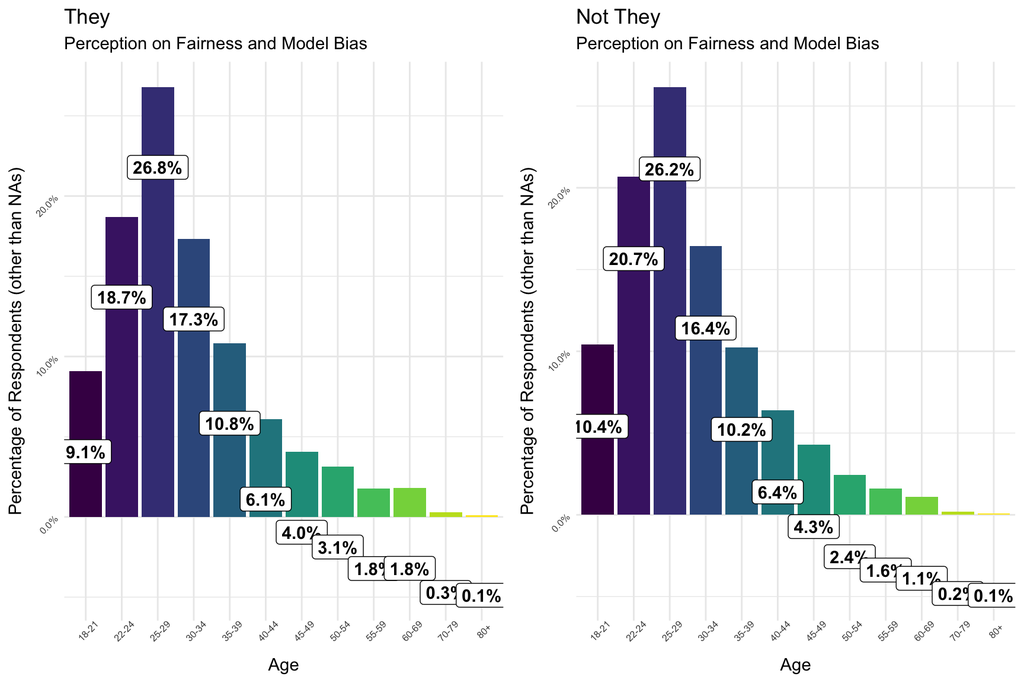

```r
they %>% group_by(`What is your age (# years)?`) %>% count() %>% ungroup() %>%
  rename("Age" = `What is your age (# years)?`) %>%
  mutate(n = n / sum(n),
         perc = percent(n)) %>%
   ggplot() + geom_col(aes(Age,n, fill = Age), stat = "identity", show.legend = FALSE) +
   geom_label(aes(x = Age, y = n - 0.05, label = percent(n)),
           # hjust=0, vjust=0, size = 4, colour = 'black',
            fontface = 'bold') +
    scale_fill_viridis(discrete = T, option = "D") +
  scale_y_continuous(labels = percent_format()) +
  theme_minimal() +
  theme(axis.text = element_text(angle = 45, size = 6)) +
  labs(title = "They",
       subtitle = "Perception on Fairness and Model Bias ",
       x = "Age",
       y = "Percentage of Respondents (other than NAs)") -> p1
not_they %>% group_by(`What is your age (# years)?`) %>% count() %>% ungroup() %>%
  rename("Age" = `What is your age (# years)?`) %>%
  mutate(n = n / sum(n),
         perc = percent(n)) %>%
    ggplot() + geom_col(aes(Age,n, fill = Age), stat = "identity", show.legend = FALSE) +
   geom_label(aes(x = Age, y = n - 0.05, label = percent(n)),
           # hjust=0, vjust=0, size = 4, colour = 'black',
            fontface = 'bold') +
    scale_fill_viridis(discrete = T, option = "D") +
  scale_y_continuous(labels = percent_format()) +
  theme_minimal() +
  theme(axis.text = element_text(angle = 45, size = 6)) +
  labs(title = "Not They",
       subtitle = "Perception on Fairness and Model Bias ",
       x = "Age",
       y = "Percentage of Respondents (other than NAs)") -> p2
cowplot::plot_grid(p1,p2)
```

Age doesn’t seem to give anything straightway, which probably could be due to a lot of different age brackets. Let us try a bit of engineering to club them into two groups < 30 and > 30.

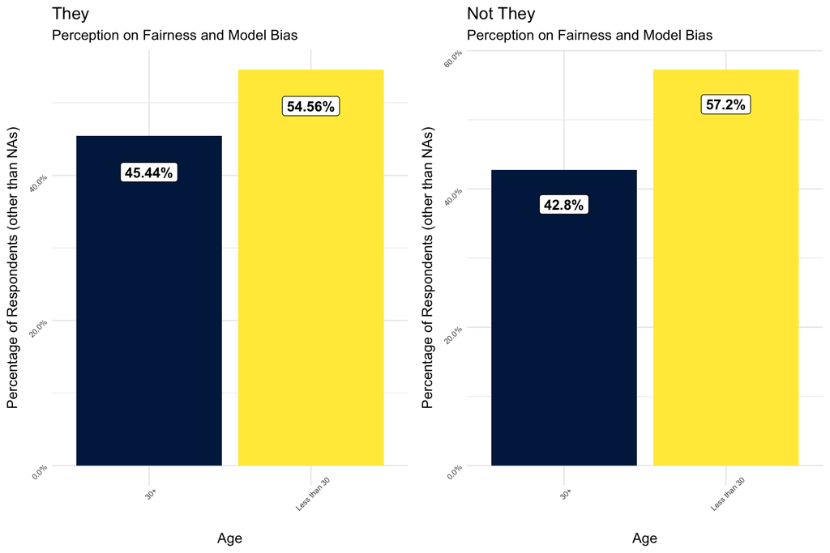

```r
they %>%
  mutate(age_grp = ifelse(parse_number(`What is your age (# years)?`) < 30,
                          "Less than 30",
                          "30+")) %>%
  group_by(age_grp) %>% count() %>% ungroup() %>%
  rename("Age" = age_grp) %>%
  mutate(n = n / sum(n),
         perc = percent(n)) %>%
   ggplot() + geom_col(aes(Age,n, fill = Age), stat = "identity", show.legend = FALSE) +
   geom_label(aes(x = Age, y = n - 0.05, label = percent(n)),
           # hjust=0, vjust=0, size = 4, colour = 'black',
            fontface = 'bold') +
    scale_fill_viridis(discrete = T, option = "E") +
  scale_y_continuous(labels = percent_format()) +
  theme_minimal() +
  theme(axis.text = element_text(angle = 45, size = 6)) +
  labs(title = "They",
       subtitle = "Perception on Fairness and Model Bias ",
       x = "Age",
       y = "Percentage of Respondents (other than NAs)") -> p1
not_they %>%
   mutate(age_grp = ifelse(parse_number(`What is your age (# years)?`) < 30,
                          "Less than 30",
                          "30+")) %>%
  group_by(age_grp) %>% count() %>% ungroup() %>%
  rename("Age" = age_grp) %>%
  mutate(n = n / sum(n),
         perc = percent(n)) %>%
    ggplot() + geom_col(aes(Age,n, fill = Age), stat = "identity", show.legend = FALSE) +
   geom_label(aes(x = Age, y = n - 0.05, label = percent(n)),
           # hjust=0, vjust=0, size = 4, colour = 'black',
            fontface = 'bold') +
    scale_fill_viridis(discrete = T, option = "E") +
  scale_y_continuous(labels = percent_format()) +
  theme_minimal() +
  theme(axis.text = element_text(angle = 45, size = 6)) +
  labs(title = "Not They",
       subtitle = "Perception on Fairness and Model Bias ",
       x = "Age",
       y = "Percentage of Respondents (other than NAs)") -> p2
cowplot::plot_grid(p1,p2)
```

This plot helps us say that **the younger ones need to be updated with the implications of Model Bias and Fairness** more than their older counterparts. That leads us to another important section of what they do.

### Student vs Professionals

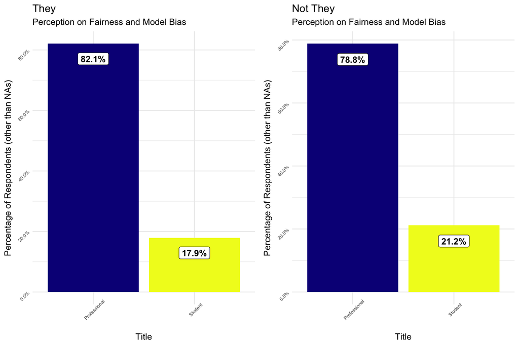

```r
they %>%
  mutate(title = ifelse(`Select the title most similar to your current role (or most recent title if retired): - Selected Choice` == "Student",
                          "Student",
                          "Professional")) %>%
  group_by(title) %>% count() %>% ungroup() %>%
  rename("Title" = title) %>%
  mutate(n = n / sum(n),
         perc = percent(n)) %>%
   ggplot() + geom_col(aes(Title,n, fill = Title), stat = "identity", show.legend = FALSE) +
   geom_label(aes(x = Title, y = n - 0.05, label = percent(n)),
           # hjust=0, vjust=0, size = 4, colour = 'black',
            fontface = 'bold') +
    scale_fill_viridis(discrete = T, option = "C") +
  scale_y_continuous(labels = percent_format()) +
  theme_minimal() +
  theme(axis.text = element_text(angle = 45, size = 6)) +
  labs(title = "They",
       subtitle = "Perception on Fairness and Model Bias ",
       x = "Title",
       y = "Percentage of Respondents (other than NAs)") -> p1
not_they %>%
  mutate(title = ifelse(`Select the title most similar to your current role (or most recent title if retired): - Selected Choice` == "Student",
                          "Student",
                          "Professional")) %>%
  group_by(title) %>% count() %>% ungroup() %>%
  rename("Title" = title) %>%
  mutate(n = n / sum(n),
         perc = percent(n)) %>%
    ggplot() + geom_col(aes(Title,n, fill = Title), stat = "identity", show.legend = FALSE) +
   geom_label(aes(x = Title, y = n - 0.05, label = percent(n)),
           # hjust=0, vjust=0, size = 4, colour = 'black',
            fontface = 'bold') +
  scale_fill_viridis(discrete = T, option = "C") +
  scale_y_continuous(labels = percent_format()) +
  theme_minimal() +
  theme(axis.text = element_text(angle = 45, size = 6)) +
  labs(title = "Not They",
       subtitle = "Perception on Fairness and Model Bias ",
       x = "Title",
       y = "Percentage of Respondents (other than NAs)") -> p2
cowplot::plot_grid(p1,p2)
```

### Undergraduate Majors

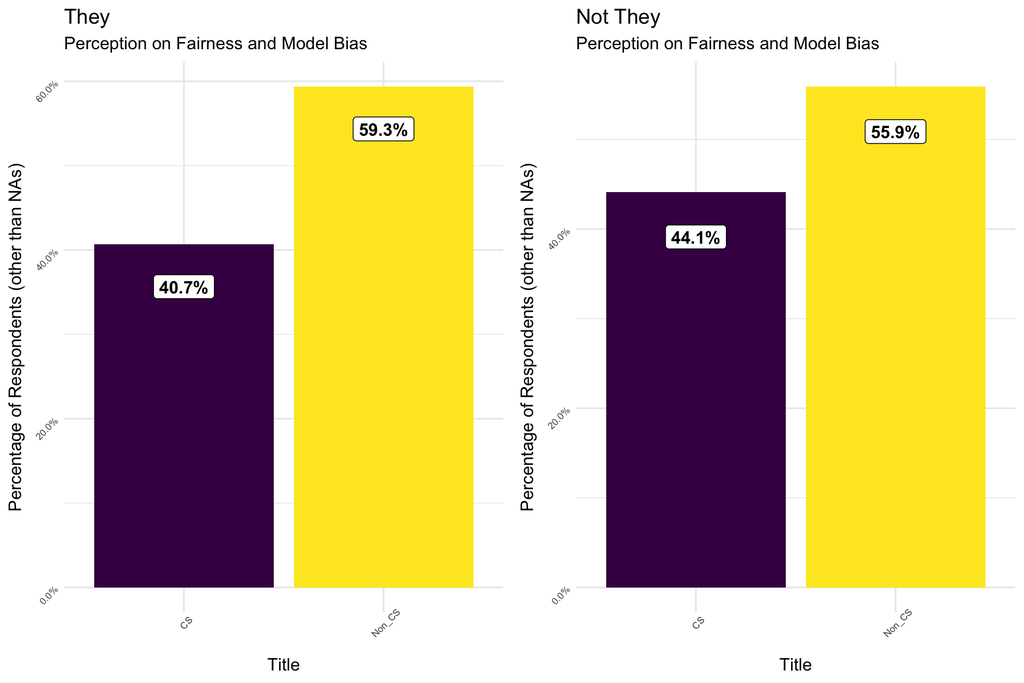

```r
they %>%
  mutate(UG = ifelse(`Which best describes your undergraduate major? - Selected Choice` %in% c("Computer science (software engineering, etc.)","Information technology, networking, or system administration"),
                          "CS",
                          "Non_CS")) %>%
  group_by(UG) %>% count() %>% ungroup() %>%
  rename("UG" = UG) %>%
  mutate(n = n / sum(n),
         perc = percent(n)) %>%
   ggplot() + geom_col(aes(UG,n, fill = UG), stat = "identity", show.legend = FALSE) +
   geom_label(aes(x = UG, y = n - 0.05, label = percent(n)),
           # hjust=0, vjust=0, size = 4, colour = 'black',
            fontface = 'bold') +
  scale_fill_viridis(discrete = T, option = "D") +
  scale_y_continuous(labels = percent_format()) +
  theme_minimal() +
  theme(axis.text = element_text(angle = 45, size = 6)) +
  labs(title = "They",
       subtitle = "Perception on Fairness and Model Bias ",
       x = "Title",
       y = "Percentage of Respondents (other than NAs)") -> p1
not_they %>%
   mutate(UG = ifelse(`Which best describes your undergraduate major? - Selected Choice` %in% c("Computer science (software engineering, etc.)","Information technology, networking, or system administration"),
                          "CS",
                          "Non_CS")) %>%
  group_by(UG) %>% count() %>% ungroup() %>%
  rename("UG" = UG) %>%
  mutate(n = n / sum(n),
         perc = percent(n)) %>%
   ggplot() + geom_col(aes(UG,n, fill = UG), stat = "identity", show.legend = FALSE) +
   geom_label(aes(x = UG, y = n - 0.05, label = percent(n)),
           # hjust=0, vjust=0, size = 4, colour = 'black',
            fontface = 'bold') +
  scale_fill_viridis(discrete = T, option = "D") +
  scale_y_continuous(labels = percent_format()) +
  theme_minimal() +
  theme(axis.text = element_text(angle = 45, size = 6)) +
  labs(title = "Not They",
       subtitle = "Perception on Fairness and Model Bias ",
       x = "Title",
       y = "Percentage of Respondents (other than NAs)") -> p2
cowplot::plot_grid(p1,p2)
```

- Comptuer Science / IT Engineers have a difference of **~ 3.4PP** between **They and Not They**, which shows that’s needs more care in the mindset change than Non-CS (even though that’s also required) but at least this can help prioritise where to start with any campaigning

### R vs Python

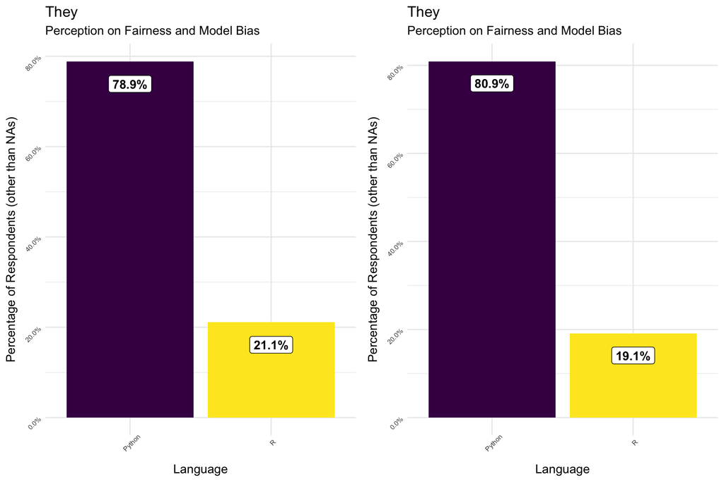

```r
they %>% filter(`What specific programming language do you use most often? - Selected Choice` %in% c("R","Python")) %>%
  group_by(`What specific programming language do you use most often? - Selected Choice`) %>% count() %>% ungroup() %>%
  rename("Language" = `What specific programming language do you use most often? - Selected Choice`) %>%
  mutate(n = n / sum(n),
         perc = percent(n)) %>%
   ggplot() + geom_col(aes(Language,n, fill = Language), stat = "identity", show.legend = FALSE) +
   geom_label(aes(x = Language, y = n - 0.05, label = percent(n)),
           # hjust=0, vjust=0, size = 4, colour = 'black',
            fontface = 'bold') +
    scale_fill_viridis(discrete = T, option = "D") +
  scale_y_continuous(labels = percent_format()) +
  theme_minimal() +
  theme(axis.text = element_text(angle = 45, size = 6)) +
  labs(title = "They",
       subtitle = "Perception on Fairness and Model Bias ",
       x = "Language",
       y = "Percentage of Respondents (other than NAs)") -> p1
not_they   %>% filter(`What specific programming language do you use most often? - Selected Choice` %in% c("R","Python")) %>%
  group_by(`What specific programming language do you use most often? - Selected Choice`) %>% count() %>% ungroup() %>%
  rename("Language" = `What specific programming language do you use most often? - Selected Choice`) %>%
  mutate(n = n / sum(n),
         perc = percent(n)) %>%
   ggplot() + geom_col(aes(Language,n, fill = Language), stat = "identity", show.legend = FALSE) +
   geom_label(aes(x = Language, y = n - 0.05, label = percent(n)),
           # hjust=0, vjust=0, size = 4, colour = 'black',
            fontface = 'bold') +
    scale_fill_viridis(discrete = T, option = "D") +
  scale_y_continuous(labels = percent_format()) +
  theme_minimal() +
  theme(axis.text = element_text(angle = 45, size = 6)) +
  labs(title = "They",
       subtitle = "Perception on Fairness and Model Bias ",
       x = "Language",
       y = "Percentage of Respondents (other than NAs)") -> p2
cowplot::plot_grid(p1,p2)
```

- R users tend to be perceive Model Bias and Fairness as **Very Important** than their Python Counterparts.

### Recommendations

- Exposing College Students and Early in Career Data Scientsits to Model Fairness and Bias Machine Learning
- Educating specially Male (and also female) Data scientsts the importance of unBiasing input training data / Model before moving it to production / presentation
- Suggesting places like Kaggle and Bootcamps to include Projects/Works about Model Fariness and Bias in their Data Science Curriculum